# Interpolation of data

Professor: Börge Göbel

Student: Aaron Meek

In this lab, I will demonstrate and explain the process of Data Interpolation.

```python
import numpy as np
import matplotlib.pyplot as plt
```

## 1. Taylor expansion

$ f(x)=\sum_{n=0}^\infty \frac{1}{n!}f^{(n)}(x_0)\,(x-x_0)^n$

The Taylor series is a series which can calculate the entire range of any continuous function. This of course implies that all the values of said function are known for all $x$.

We use the exponential function $ f^{(n)} $ and $ x_0 $, the argument around which we expand the function, to define the formula above.

### 1.1 The exponential function

$ f(x)=f'(x)=f''(x)=\dots=f^{(n)}(x)=\exp(x) $

Here, we can define a basic function used by the Taylor expantion formula at the top. We can use this to iterate through all $x$ values of a suitable function, and retrieve the corresponding $y$ values.

```python
def taylor_exp(x, x_0, n_max):
    # x: the argument
    # x0: the argument at which the nth derivatives will be calculated
    # n_max: the itterator and series termination/upperbound
    y = 0
    for n in range(n_max + 1):
        # np.exp(x_0) is a build in function to calculate the nth derivative of a function
        y = y + np.exp(x_0)*(x - x_0)**n / np.math.factorial(n)
    return y;
```

Using this function we can find the value of Euler's number, which is typically found using this formula:

$e=\sum_{n=0}^\infty \frac{1}{n!}$

Set the upper bound (as computers cannot run until infinity) to 10.

```python
x = 1
x_0 = 0
n = 10

print("Taylors Expansion: %0.5f." % taylor_exp(x, x_0, n)) # Taylors expansion
print("Built in Exponential Fuction: %0.5f." % np.exp(1)) # built in exponential function
```

```
Taylors Expansion: 2.71828.
Built in Exponential Fuction: 2.71828.
```

The Taylor Expansion, as defined, works as expected.

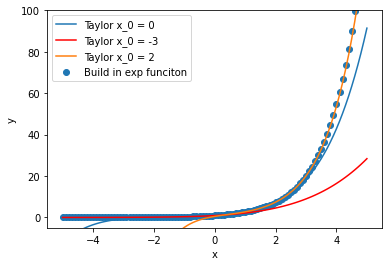

```python
n = 5

plt.xlabel('x')
plt.ylabel('y')
plt.ylim([-5,100])

# create an array to store our x values
x_list = np.linspace(-5,5,101) # define a line space of x values from -5 to 5 in increments of 0.1 (our step size)

# the step size is arbitrary, and we define it as a small value to acheive a seemingly continuous graph

# plot the graph (x, exp(x))
plt.scatter(x_list, np.exp(x_list), label="Build in exp funciton")

# plot the graph (x, taylor_exp(x, 0, n))
plt.plot(x_list, taylor_exp(x_list, 0, n), label="Taylor x_0 = 0")

# plot the graph (x, taylor_exp(x, -3, n))
plt.plot(x_list, taylor_exp(x_list, -3, n), 'r',label="Taylor x_0 = -3")

# plot the graph (x, taylor_exp(x, 2, n))
plt.plot(x_list, taylor_exp(x_list, 2, n), label="Taylor x_0 = 2")

plt.legend()
```

### 1.2 Maclaurin Expansion at $sin(x)$, at $x_0=0$

The Maxlaurin series is a special case of the Taylor expantion series, where $x_0=0$; a single point.

The derivatives of the two trigonometric functions $sin(x)$ and $cos(x)$ are as follows:

$sin(x) = 0$

$sin(x)' = cos(x)$

$sin(x)'' = cos(x)' = -sin(x)$

$sin(x)''' = cos(x)'' = -sin(x)' = -cos(x)$

While this may look like a mess, all it shows is when continuously deriving these two functions, eventually we start where we began. It's a loop, and this makes sense. The reason it makes sense is due to the fact $sin(x)$ and $cos(x)$ outputs range from -1 to 1.

Another explanation of the process, where only replacing $sin(x)$ with $f(x)$:

$ f(0) = f''(0) = f^{(4)}(0) = \dots = 0 $

$ f'(0) = f^{(5)}(0) = f^{(9)}(0) = \dots = 1 $

$ f'''(0) = f^{(7)}(0) = f^{(11)}(0) = \dots = -1 $

Here is the mathematical definition of the process:

$ \sin(x) = x - \frac{1}{3!}x^3 + \frac{1}{5!}x^5 - \frac{1}{7!}x^7 \pm \dots = \sum_{n=0}^\infty \frac{(-1)^n}{(2n+1)!}x^{2n+1}$

This acheives the same desired outcome as the Taylor expanion near the beggining of the report; only now it is focused on the function $sin(x)$ using Maclaurin's expantion. The $y$ value outputs should match the $y$ value outputs of the $sin$ function, within a specified range.

```python
def taylor_exp_sin(x, n_max):
    # x: the argument
    # n_max: the itterator and series termination/upperbound
    y = 0
    for n in range(n_max + 1):
        y = y + (-1)**n * x**(2*n + 1) / np.math.factorial(2 * n + 1)
    return y
```

Notice the absence of the exp function in the formula. It is not required since the outputs from $f(x)^{(n)}$, $f(x)$ being $sin(x)$, loop infinitly within the range of -1 to 1.

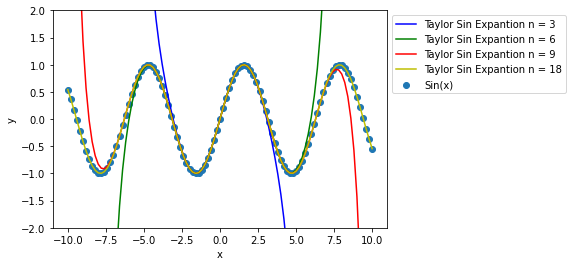

```python
plt.xlabel('x')
plt.ylabel('y')
plt.ylim([-2,2])

# create an array to store our x values
x_list = np.linspace(-10,10,101) # define a line space of x values from -10 to 10 in increments of 0.2 (our step size)

# plot the results as shown before
plt.scatter(x_list, np.sin(x_list), label="Sin(x)")
plt.plot(x_list, taylor_exp_sin(x_list, 3), 'b',label="Taylor Sin Expantion n = 3")
plt.plot(x_list, taylor_exp_sin(x_list, 6), 'g',label="Taylor Sin Expantion n = 6")
plt.plot(x_list, taylor_exp_sin(x_list, 9), 'r',label="Taylor Sin Expantion n = 9")
plt.plot(x_list, taylor_exp_sin(x_list, 18), 'y', label="Taylor Sin Expantion n = 18")

plt.legend(bbox_to_anchor=(1, 1))
```

Checking the accuracy of this expantion function next to $sin(10.5)$ provides extremely small error; effectively zero.

```python
np.sin(10.5) - taylor_exp_sin(10.5, 50)
```

```
-2.844391389089651e-13
```

### 1.3 Implementing a general purpose Taylor series function

Before a general Taylor series function can be deployed, a function to find derivatives must be defined.

The formula to calculate the derivative of a function: $ f'(x) = \lim_{h\rightarrow 0} \frac{f(x+h)-f(x)}{h} $

```python
def derivative(f, x, h):
    # f: the function
    # x: argument of f
    # h: step size
    return ((f(x + h) - f(x)) / h)
```

A function to calculate the $nth$ derivative of a function can also be defined.

The formula to calculate higher derivatives: $ f^{(n)}(x) = \lim_{h\rightarrow 0} \frac{1}{h^n}\sum_{k=0}^n(-1)^{k+n} \,\frac{n!}{k!(n-k)!} \,f(x+kh)$

```python
def nDerivative(f, x, h, n):
    # f: the function
    # x: argument of f
    # h: step size
    # n: nth derivative
    y = 0
    for k in range(n+1):
        y = y + ((-1)**(k + n)*(np.math.factorial(n)*f(x + k * h))) / (np.math.factorial(k)*np.math.factorial(n - k))
    return y / h**n
```

Define an arbitrary function to based our data on.

Used here: $f(x) = 2sin(x)^2+x$

```python
def f(x):
    return 2*np.sin(x)**2 + x
```

```python
x0 = 10.5 # assign x for our initial data as 10.5
h = 0.001 # assign the distance between each point as 0.001
```

Check to see if the $nth$ derivative function works by comparing the results side by side.

```python
print("f(x0) = %0.10f rads" % f(x0))
print("nth derivative function(f,x0,h,0) = %0.10f rads" % nDerivative(f, x0, h, 0))
```

```
f(x0) = 12.0477292602 rads
nth derivative function(f,x0,h,0) = 12.0477292602 rads
```

Calculate $f'(x)$ using the $first$ derivative function. Compare it to the results of the $higher$ $(nth)$ $derivatives$ function.

```python
print("First derivative funciton(x0) = %0.5f rads" % derivative(f, x0, h))
print("nth derivative function(x0) = %0.5f rads" % nDerivative(f, x0, h, 1))
```

```
First derivative funciton(x0) = 2.67221 rads
nth derivative function(x0) = 2.67221 rads
```

Using these functions, one can calculate the results of the second, third, and fourth derivative of $f(x)$, respectively.

```python
print('%0.3f' %nDerivative(f, x0, h, 2))
print('%0.3f' %nDerivative(f, x0, h, 3))
print(' %0.3f' %nDerivative(f, x0, h, 4))
```

```
-2.198
-6.680
 8.823
```

Without calculating these results analytically, or by using more proven methods, it is difficult to tell whether these results are accurate.

### 1.4 Implementing a general Taylor expansion function using the $nth$ derivatives function

```python
def taylor(f, x, x0, n_max, h): # lets define it for all(most) continuous functions
    # f   : the function
    # x   : argument
    # x0  : argument at which the derivative will be calculated
    # n_max: upperbound for series termination (sum upperbound)
    # h   : Stepsize
    y = 0
    for n in range(n_max + 1):
        y = y + (nDerivative(f, x0, h, n) * (x - x0)**n) / np.math.factorial(n)
    return y
```

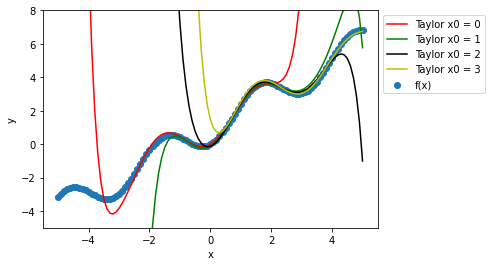

```python
plt.xlabel('x')
plt.ylabel('y')
plt.ylim([-5,8])

x_list = np.linspace(-5,5,101)

n = 10
h = 0.05

plt.scatter(x_list, f(x_list), label="f(x)")
plt.plot(x_list, taylor(f, x_list, 0, n, h), 'r', label="Taylor x0 = 0")
plt.plot(x_list, taylor(f, x_list, 1, n, h), 'g', label="Taylor x0 = 1")
plt.plot(x_list, taylor(f, x_list, 2, n, h), 'k', label="Taylor x0 = 2")
plt.plot(x_list, taylor(f, x_list, 3, n, h), 'y',label="Taylor x0 = 3")

plt.legend(bbox_to_anchor=(1, 1))
```

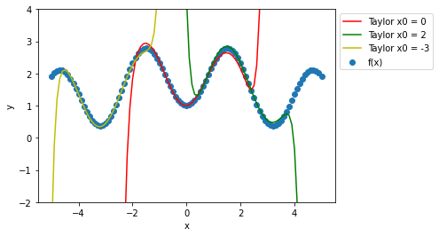

```python
def f(x):
    return 2 * np.sin(x)**2 + np.exp(-0.1 * x**2)

plt.xlabel('x')
plt.ylabel('y')
plt.ylim([-2,4])

x_list = np.linspace(-5,5,101)
n = 15
h = 0.05

plt.scatter(x_list, f(x_list), label="f(x)")
plt.plot(x_list, taylor(f, x_list, 0, n, h), 'r', label="Taylor x0 = 0")
plt.plot(x_list, taylor(f, x_list, 2, n, h), 'g', label="Taylor x0 = 2")
plt.plot(x_list, taylor(f, x_list, -3, n, h), 'y',label="Taylor x0 = -3")

plt.legend(bbox_to_anchor=(1, 1))
```

## 2. Interpolation

### 2.1 Generate data points based on a model function

Defined model: $m(x)=15+2.4x-0.5x^2-0.35x^3$

```python
def m(x):
    return 15 + 2.4 * x - 0.5 * x**2 - 0.35 * x**3
```

```python
npoints = 21 # define the number of points
x_list = np.linspace(-5, 5, npoints) # define new x values, -5 to 5
data_model = np.array([x_list, m(x_list)]) # store the model data
```

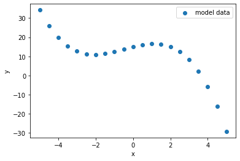

```python
plt.xlabel('x')
plt.ylabel('y')

plt.scatter(data_model[0], data_model[1], label="model data")

plt.legend(bbox_to_anchor=(1, 1))
```

To simulate purturbed data, modify the x and y values by adding some random turbulance; not all data measured is smooth

```python
data = np.array([data_model[0] + 0.25 * (2 * np.random.rand(npoints)-1), # this will be our purturbed data
                 data_model[1] + 5.0 * (2 * np.random.rand(npoints)-1)])
```

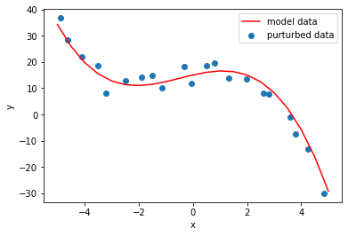

```python
plt.xlabel('x')
plt.ylabel('y')

plt.plot(data_model[0], data_model[1], 'r',label="model data")
plt.scatter(data[0], data[1], label="purturbed data")

plt.legend(bbox_to_anchor=(1, 1))
```

Certain techniques are available to fit purtubed data to a model function.

Explanation below, using model data.

## 2.2 Spline interpolation

### 2.2.1 Model data

A spline interpolation will alway attempt to fit data perfectly, and can cause problems if not used correctly.

The spline is defined piecewise (piece by piece/dot by dot), and is a linear spline.

```python
from scipy import interpolate
```

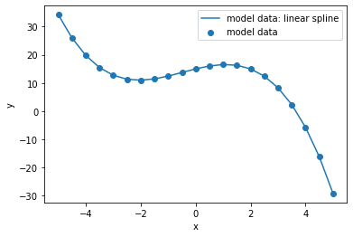

```python
splineLinear_model = interpolate.interp1d(data_model[0], data_model[1], kind = 'linear')

plt.xlabel('x')
plt.ylabel('y')

plt.scatter(data_model[0], data_model[1], label="model data")
plt.plot(data_model[0], splineLinear_model(data_model[0]), label="model data: linear spline")

plt.legend(bbox_to_anchor=(1, 1))
```

A linear spline is piecewise, where each interval (point) uses a linear equation.

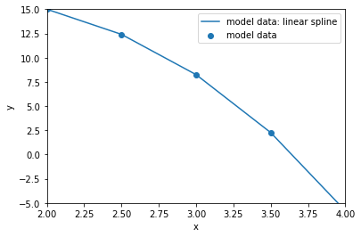

```python
plt.xlabel('x')
plt.ylabel('y')
plt.xlim([2,4])
plt.ylim([-5,15])

x_list = np.linspace(2,4,201)

plt.plot(x_list, splineLinear_model(x_list), label="model data: linear spline")
plt.scatter(data_model[0], data_model[1], label="model data")

plt.legend(bbox_to_anchor=(1,1))
```

Notice the straight lines. This is not ideal to describe the physics within a system.

Cubic splines can be used to remedy this issue.

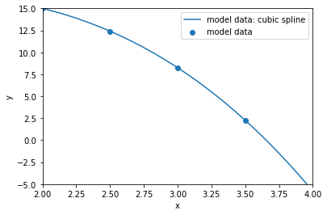

```python
splineCubic_model = interpolate.interp1d(data_model[0], data_model[1], kind = "cubic")

plt.xlabel('x')
plt.ylabel('y')
plt.xlim([2,4])
plt.ylim([-5,15])

x_list = np.linspace(2,4,201)

plt.plot(x_list, splineCubic_model(x_list), label="model data: cubic spline")
plt.scatter(data_model[0], data_model[1], label="model data")

plt.legend(bbox_to_anchor=(1, 1))
```

Notice the derivative is continuous; the lines are curved. This is how the cubic spline works.

### 2.2.2 Perturbed data

Applying the cubic spline to the purturbed data.

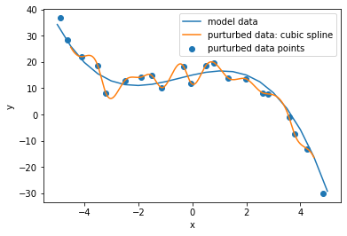

```python
splineCubic = interpolate.interp1d(data[0], data[1], kind = 'cubic')

plt.xlabel('x')
plt.ylabel('y')

x_list = np.linspace(-4.5,4.5,901)

plt.plot(data_model[0], data_model[1], label="model data")
plt.scatter(data[0], data[1], label="purturbed data points")
plt.plot(x_list, splineCubic(x_list), label="purturbed data: cubic spline")

plt.legend(bbox_to_anchor=(1, 1))
```

The purturbed data has been "overfitted"; a term used in numerics.

The perturbed data is being forced to fit too well, in light of the fact that the simulated data is quite rough. Therefore, much of what we're seeing in the splined data is noise.

Using a univariate spline, it is possible to adjust the smoothness of the output.

```python
splineSmooth = interpolate.UnivariateSpline(data[0], data[1]) # apply a univariate spline to the purturbed data
splineSmooth.set_smoothing_factor(500) # set the smoothing factor
```

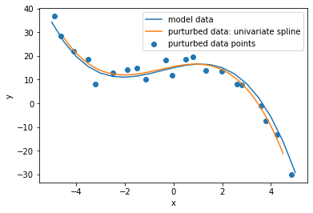

```python
plt.xlabel('x')
plt.ylabel('y')

x_list = np.linspace(-4.5,4.5,901)

plt.plot(data_model[0], data_model[1], label="model data")
plt.scatter(data[0], data[1], label="purturbed data points")
plt.plot(x_list, splineSmooth(x_list), label="purturbed data: univariate spline")

plt.legend(bbox_to_anchor=(1, 1))
```

By all ignoring that all the points must fit perfectly, we've been able to define a shape that fits well.

This is a far better function for describing the physics going on within a system.

This is no longer a piecewise spline, but a univariate spline.

### 2.2.3 Fitting data to an n-1 order polynomial

```python
# copy over a section of the purturbed data into a new x array
datapoly = data[:,7:14]
```

There are $7$ data points within datapoly. To plot this data, an $n-1$ order polynomial is used for interpolation.

In the case of $7$ data points, $7-1$ gives us the function:

$ f(x) = y = a_0 + a_1 x + a_2 x^2 + a_3 x^3 + a_4 x^4 + a_5 x^5 + a_6 x^6$

This polynomial gives the correct value for all points $x$ and $ y$.

We can express these $7$ equations (from $i = 0, \dots, 6$) as a matrix equation.

```python
# transpose the data to form a matrix
x = np.transpose(
    np.array(
    [datapoly[0,:]**0, # before haveing the data transposed apply the calculation
     datapoly[0,:]**1, # a_n-1 * x^n-1
     datapoly[0,:]**2,
     datapoly[0,:]**3,
     datapoly[0,:]**4,
     datapoly[0,:]**5,
     datapoly[0,:]**6]
    )
)
```

```python
np.set_printoptions(suppress=True)
np.around(x, 5)
```

```
array([[ 1.     , -1.50696,  2.27092, -3.42217,  5.15706, -7.77146,
        11.71124],
       [ 1.     , -1.1458 ,  1.31285, -1.50426,  1.72358, -1.97487,
         2.26281],
       [ 1.     , -0.33039,  0.10916, -0.03606,  0.01192, -0.00394,
         0.0013 ],
       [ 1.     , -0.04823,  0.00233, -0.00011,  0.00001, -0.     ,
         0.     ],
       [ 1.     ,  0.50709,  0.25714,  0.1304 ,  0.06612,  0.03353,
         0.017  ],
       [ 1.     ,  0.80253,  0.64406,  0.51688,  0.41481,  0.3329 ,
         0.26717],
       [ 1.     ,  1.33649,  1.78622,  2.38727,  3.19057,  4.26417,
         5.69904]])
```

```python
y = datapoly[1,:]
np.around(y, 5)
```

```
array([14.84548, 10.24272, 18.36585, 11.96137, 18.69888, 19.71003,
       13.78664])
```

Solve the system of linear equations (in $a_i$).

Here, numpy routine is used, though the Gaussian elimination method could be defined as a function as well.

For matrices, lower-upper decomposition of a matrix is the product of the lower triangular matrix and the upper triangular matrix.

```python
a = np.linalg.solve(x,y)
np.around(a, 5)
```

```
array([ 11.5874 ,  -5.14491,  54.29732,   0.27678, -71.91857,   2.75091,
        22.66321])
```

Plot the data.

$y = a_0 + a_1 x + a_2 x^2 + a_3 x^3 + a_4 x^4 + a_5 x^5 + a_6 x^6$ is used here.

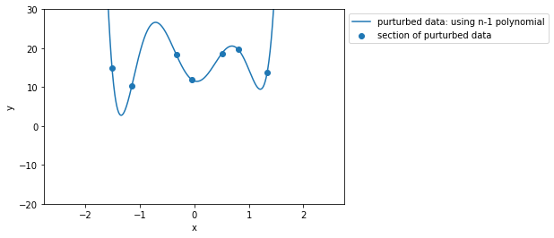

```python
plt.xlabel('x')
plt.ylabel('y')
plt.ylim([-20,30])

# define new x values
x_list = np.linspace(-2.5,2.5,901)

# solve for all y values by summing each calculated a_n-1 * x^n-1 in subsection 2.2.3
y_list = (a[0]*x_list**0 +
          a[1]*x_list**1 +
          a[2]*x_list**2 +
          a[3]*x_list**3 +
          a[4]*x_list**4 +
          a[5]*x_list**5 +
          a[6]*x_list**6)

plt.scatter(datapoly[0], datapoly[1], label="section of purturbed data")
plt.plot(x_list, y_list, label="purturbed data: using n-1 polynomial")

plt.legend(bbox_to_anchor=(1, 1))
```

The 6th order polynomial was able to fit all the data points perfectly

It is not useful for exterpolation, however.

Expanding the field of view, further out from these data points, shows how inacurate this can be. Fidelity drops off outside the range of the data.

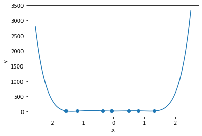

```python
plt.xlabel('x')
plt.ylabel('y')
plt.scatter(datapoly[0], datapoly[1], label="section of purturbed data")
plt.plot(x_list, y_list, label="purturbed data: using n-1 polynomial")
```

## 2.3 Fitting putrutbed data to a model function

A model function should be physically motivated, and parameters set should be ideal to minimize error.

### 2.3.1 Define model function

For practice, we consider a polynomial: $ f(x) = a_0 + a_1 x + a_2 x^2 + \dots + a_n x^n = \sum_{k=0}^n a_k x^k$

```python
def polynomialModel(x, a):
    # x: the argument of the function
    # a_n: the coefficients
    y = 0
    for k in range(len(a)):
        y = y + a[k] * x**k
    return y
```

```python
a_model = np.array([15, 2.4, -0.5, -0.35]) # the coefficients are set and stored within an array
# here, the coefficients are chosen from the original model function we defined 2.1
```

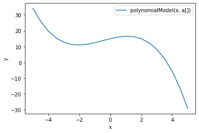

```python
plt.xlabel('x')
plt.ylabel('y')

x_list = np.linspace(-5,5,npoints)

plt.plot(x_list, polynomialModel(x_list, a_model), label="polynomialModel(x, a[])")

plt.legend()
```

### 2.3.2 Defining error

The error function used here: $ \Delta = \sum_{i=1}^n \left(y_i-f(x_i)\right)^2$

This is a commonly used error funciton.

$ f(x_i)$ is the fit function that is determined by all coefficients $ a_k $ in the n-1 order polynomial model function, defined in subsection 2.3.1.

The points to fit are the purturbed data's $ x_i$ and $y_i$, and here the sum of the error will be determined.

```python
def errorFit(f, coefficients, data):
    # f: the fit function
    # coefficients: a_k -> the model function coefficients used to optomize
    # data: the purturbed data to fit
    error = 0
    for i in range(len(data[0])):
        error = error + (data[1,i] - f(data[0,i], coefficients))**2
    return error
```

```python
print(f"Sum of error = {errorFit(polynomialModel, a_model, data)}.")
```

```
Sum of error = 234.3742818230482.
```

To understand this error, see the top graph in subsection 2.2.2

### 2.3.3 Gradient descent: Updating coefficients to reduce the error at each point

Here, we will use the gradient descent method to update the coefficients $ a_k $. These coefficients will be updated along the gradient direction of the error function (nabla) $ \nabla_{\vec{a}} \Delta$.

Here, $\Delta$ is the error fit function defined in subsection 2.3.2.

The mathematical deffinition is defined as the derivative of $\Delta$ with respect to $a_k$:

$ \frac{\partial}{\partial a_k} \Delta = -2 \sum_{i=1}^n \left(y_i-f(x_i)\right) \frac{\partial}{\partial a_k}f(x_i) = -2 \sum_{i=1}^n \left(y_i-f(x_i)\right) x_i^{k}$

The Monte-Carlo algorithm could also be used if desired.

```python
def errorFitGradient(f, coefficients, data):
    # f: the error fit function
    # coefficients: a_k -> the model function coefficients used to optomize
    # data: the purturbed data to fit
    return -2 * np.array([
        np.sum(
            np.array([(data[1,i] - f(data[0,i], coefficients)) * data[0,i]**k
            for i in range(len(data[0]))]
                    )
              )
        for k in range(len(coefficients))]
    )
```

```python
errorFitGradient(polynomialModel, a_model, data)
```

```
array([  17.19352598,  240.65537782,  370.6003633 , 4020.52601532])
```

This function can be used to update the value of $a_k$: the coefficients.

### 2.3.4 Loop for the fitting of data

```python
iterations = 100000 # the total number of iterations
h = 0.00001 # the step size
a_random = 2*np.random.rand(4) - 1 # store 4 randomly generated numbers into a coefficient array
a_random_untouched = a_random
```

Begin the calculatiion process to correct the coefficients, within the array $a$, by using the error fit gradient funciton.

```python
for i in range(iterations):
    a_random = a_random - h * errorFitGradient(polynomialModel, a_random, data)
```

```python
print(f"Error fit using randomly generated coefficients = {errorFit(polynomialModel, a_random, data):.5f}")
print(f"Error fit using the model function coefficients = {errorFit(polynomialModel, a_model, data):.5f}")

print(f"The model function coefficients to fit          : {np.around(a_model, 5)}")
print(f"The randomly generated coefficients, updated    : {np.around(a_random, 5)}")
print(f"The randomly generated coefficients, not updated: {np.around(a_random_untouched, 5)}")
```

```
Error fit using randomly generated coefficients = 137.24572
Error fit using the model function coefficients = 234.37428
The model function coefficients to fit          : [15.    2.4  -0.5  -0.35]
The randomly generated coefficients, updated    : [15.47696  2.01428 -0.60612 -0.36749]
The randomly generated coefficients, not updated: [-0.28992  0.61976 -0.47662  0.35727]
```

Recognize the power of this tool. The original randomly generated coefficients are far from accurate to the model function's coefficients. The updated randomly generated coefficients calculated and adjusted through an iterative process are far more accurate to the model function coefficients.

Gradient decent.

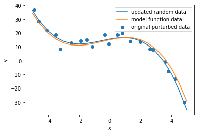

```python
plt.xlabel('x')
plt.ylabel('y')

x_list = np.linspace(-5, 5, npoints)

plt.plot(x_list, polynomialModel(x_list, a_random), label="updated random data") #using the coefficients we found through error fit gradient
plt.plot(x_list, polynomialModel(x_list, a_model), label="model function data") #using the data we created from the model (out aim)
plt.scatter(data[0], data[1], label="original purturbed data") # the noisy data we started out with

plt.legend(bbox_to_anchor=(1, 1))
```